# Hierarchical Clustering

1. Read the dataset
2. Data investigation
3. Data preprocessing
4. Features transformation
5. K means
6. Training datasets
7. Improvement ideas

```python
import pandas as pd
import numpy as np
import matplotlib.pyplot as plt
import scipy.cluster.hierarchy as shc
import warnings
warnings.filterwarnings("ignore")
```

## 1. Read the dataset

(Go to top)

First dowmload the data set from this link https://www.kaggle.com/code/sadkoktaybicici/credit-card-data-clustering-k-mean/data then import it in python.

```python
from google.colab import files

uploaded = files.upload()
```

Upload widget is only available when the cell has been executed in the current browser session. Please rerun this cell to enable.

```
Saving CC_GENERAL.csv to CC_GENERAL.csv
```

```python
#read the data

# data_path = ''  #the path where you downloaded the data
df = pd.read_csv('CC_GENERAL.csv')

print('The shape of the dataset is:', df.shape)
```

```
The shape of the dataset is: (8950, 18)
```

```python
df.head()
```

|  | CUST_ID | BALANCE | BALANCE_FREQUENCY | PURCHASES | ONEOFF_PURCHASES | INSTALLMENTS_PURCHASES | CASH_ADVANCE | PURCHASES_FREQUENCY | ONEOFF_PURCHASES_FREQUENCY | PURCHASES_INSTALLMENTS_FREQUENCY | CASH_ADVANCE_FREQUENCY | CASH_ADVANCE_TRX | PURCHASES_TRX | CREDIT_LIMIT | PAYMENTS | MINIMUM_PAYMENTS | PRC_FULL_PAYMENT | TENURE |
| --- | --- | --- | --- | --- | --- | --- | --- | --- | --- | --- | --- | --- | --- | --- | --- | --- | --- | --- |
| 0 | C10001 | 40.900749 | 0.818182 | 95.40 | 0.00 | 95.4 | 0.000000 | 0.166667 | 0.000000 | 0.083333 | 0.000000 | 0 | 2 | 1000.0 | 201.802084 | 139.509787 | 0.000000 | 12 |
| 1 | C10002 | 3202.467416 | 0.909091 | 0.00 | 0.00 | 0.0 | 6442.945483 | 0.000000 | 0.000000 | 0.000000 | 0.250000 | 4 | 0 | 7000.0 | 4103.032597 | 1072.340217 | 0.222222 | 12 |
| 2 | C10003 | 2495.148862 | 1.000000 | 773.17 | 773.17 | 0.0 | 0.000000 | 1.000000 | 1.000000 | 0.000000 | 0.000000 | 0 | 12 | 7500.0 | 622.066742 | 627.284787 | 0.000000 | 12 |
| 3 | C10004 | 1666.670542 | 0.636364 | 1499.00 | 1499.00 | 0.0 | 205.788017 | 0.083333 | 0.083333 | 0.000000 | 0.083333 | 1 | 1 | 7500.0 | 0.000000 | NaN | 0.000000 | 12 |
| 4 | C10005 | 817.714335 | 1.000000 | 16.00 | 16.00 | 0.0 | 0.000000 | 0.083333 | 0.083333 | 0.000000 | 0.000000 | 0 | 1 | 1200.0 | 678.334763 | 244.791237 | 0.000000 | 12 |

## 2. Data investigation

(Go to top)

in this part you need to check the data quality and assess any issues in the data as:

- null values in each column
- each column has the proper data type
- outliers
- duplicate rows
- distribution for each column (skewness)
- correlation map

**comment each issue you find**

```python
# Let's see the data types and non-null values for each column
df.info()
```

```
<class 'pandas.core.frame.DataFrame'>
RangeIndex: 8950 entries, 0 to 8949
Data columns (total 18 columns):
 #   Column                            Non-Null Count  Dtype
---  ------                            --------------  -----
 0   CUST_ID                           8950 non-null   object
 1   BALANCE                           8950 non-null   float64
 2   BALANCE_FREQUENCY                 8950 non-null   float64
 3   PURCHASES                         8950 non-null   float64
 4   ONEOFF_PURCHASES                  8950 non-null   float64
 5   INSTALLMENTS_PURCHASES            8950 non-null   float64
 6   CASH_ADVANCE                      8950 non-null   float64
 7   PURCHASES_FREQUENCY               8950 non-null   float64
 8   ONEOFF_PURCHASES_FREQUENCY        8950 non-null   float64
 9   PURCHASES_INSTALLMENTS_FREQUENCY  8950 non-null   float64
 10  CASH_ADVANCE_FREQUENCY            8950 non-null   float64
 11  CASH_ADVANCE_TRX                  8950 non-null   int64
 12  PURCHASES_TRX                     8950 non-null   int64
 13  CREDIT_LIMIT                      8949 non-null   float64
 14  PAYMENTS                          8950 non-null   float64
 15  MINIMUM_PAYMENTS                  8637 non-null   float64
 16  PRC_FULL_PAYMENT                  8950 non-null   float64
 17  TENURE                            8950 non-null   int64
dtypes: float64(14), int64(3), object(1)
memory usage: 1.2+ MB
```

```python
df['TENURE'].unique()
```

```
array([12,  8, 11,  9, 10,  7,  6])
```

column TENURE is categoric

```python
df['CREDIT_LIMIT'].unique()
```

```
array([ 1000.      ,  7000.      ,  7500.      ,  1200.      ,
        1800.      , 13500.      ,  2300.      , 11000.      ,
        2000.      ,  3000.      ,  8000.      ,  2500.      ,
       13000.      ,  4000.      , 11250.      ,  9000.      ,
        6000.      ,  1700.      , 10500.      ,  6900.      ,
        5000.      ,  4500.      ,  1500.      ,  8500.      ,
        2400.      ,  4200.      ,  3300.      , 12000.      ,
        3500.      ,  6500.      ,  1600.      ,  4150.      ,
        1850.      ,  6250.      ,  2250.      ,  9500.      ,
       16500.      ,  5700.      ,  5500.      , 17000.      ,
        3200.      , 19000.      ,  2800.      , 18000.      ,
       21500.      , 10000.      , 20000.      ,  7900.      ,
       15000.      , 12500.      , 14000.      ,  5300.      ,
         900.      ,  6150.      , 11500.      , 23000.      ,
        2700.      , 14500.      , 19500.      ,  1400.      ,
        2900.      ,  1950.      ,  7200.      , 10950.      ,
        2100.      ,   500.      , 21000.      ,  4800.      ,
        7300.      , 18500.      ,  6550.      ,  6200.      ,
        3150.      , 11800.      , 11300.      ,  2750.      ,
       10300.      ,  2850.      , 17500.      , 22500.      ,
        6750.      , 16000.      ,  1750.      , 15500.      ,
        3800.      ,  6600.      ,  3650.      ,  2600.      ,
        4600.      ,  3350.      ,  4300.      ,  5250.      ,
       28000.      ,  3600.      , 10200.      ,   750.      ,
        7600.      ,  2720.      ,  2200.      ,  7350.      ,
         300.      ,  3750.      ,  1900.      , 10400.      ,
        5200.      ,  4350.      ,  3050.      ,  6700.      ,
       20500.      ,  5750.      ,  8300.      ,  7950.      ,
        3100.      ,  4050.      ,  6300.      ,  3666.666667,
         200.      ,  9100.      ,  3700.      ,  7100.      ,
        4750.      ,  3900.      , 10100.      ,  1300.      ,
       19600.      , 10450.      , 11150.      ,   600.      ,
        4700.      ,   150.      ,  3400.      ,  1350.      ,
        5100.      ,  7227.272727, 13550.      ,  9200.      ,
        6100.      ,  2050.      ,  6400.      ,  4250.      ,
       14600.      ,  8600.      ,  3511.111111,  5600.      ,
        6727.272727, 13600.      ,  8800.      , 11100.      ,
       12200.      ,  8100.      ,  8050.      ,  4100.      ,
        5550.      ,  4450.      ,  5650.      ,  8200.      ,
        5400.      , 25000.      ,  9950.      ,  1150.      ,
        6800.      ,  4650.      ,  7800.      ,  2150.      ,
       22000.      ,   400.      ,  7700.      ,  4400.      ,
        1050.      ,   700.      ,  5181.818182,  4900.      ,
        1100.      ,  2550.      ,  2283.333333, 30000.      ,
        9700.      ,  9400.      ,          nan,  2725.      ,
         450.      ,  8700.      , 12300.      ,  7050.      ,
        1550.      ,  9800.      ,  5450.      ,   800.      ,
        8954.545455,  2950.      ,  2450.      ,  6850.      ,
        4950.      ,  5900.      ,  1250.      , 17150.      ,
        9600.      ,    50.      , 10750.      ,  1120.      ,
       13450.      ,  3777.777778,   650.      ,  1450.      ,
        2350.      ,  1833.333333])
```

from this summary the data has null values

```python
round(df.isnull().sum(axis=0)*100/df.shape[0],2)
```

```
CUST_ID                             0.00
BALANCE                             0.00
BALANCE_FREQUENCY                   0.00
PURCHASES                           0.00
ONEOFF_PURCHASES                    0.00
INSTALLMENTS_PURCHASES              0.00
CASH_ADVANCE                        0.00
PURCHASES_FREQUENCY                 0.00
ONEOFF_PURCHASES_FREQUENCY          0.00
PURCHASES_INSTALLMENTS_FREQUENCY    0.00
CASH_ADVANCE_FREQUENCY              0.00
CASH_ADVANCE_TRX                    0.00
PURCHASES_TRX                       0.00
CREDIT_LIMIT                        0.01
PAYMENTS                            0.00
MINIMUM_PAYMENTS                    3.50
PRC_FULL_PAYMENT                    0.00
TENURE                              0.00
dtype: float64
```

the coulmns that have null values:

1 - CREDIT_LIMIT --- very small portion can be droped  
2 - MINIMUM_PAYMENTS -- can be relaced with mean

```python
# This will print basic statistics for numerical columns
df.describe()
```

|  | BALANCE | BALANCE_FREQUENCY | PURCHASES | ONEOFF_PURCHASES | INSTALLMENTS_PURCHASES | CASH_ADVANCE | PURCHASES_FREQUENCY | ONEOFF_PURCHASES_FREQUENCY | PURCHASES_INSTALLMENTS_FREQUENCY | CASH_ADVANCE_FREQUENCY | CASH_ADVANCE_TRX | PURCHASES_TRX | CREDIT_LIMIT | PAYMENTS | MINIMUM_PAYMENTS | PRC_FULL_PAYMENT | TENURE |
| --- | --- | --- | --- | --- | --- | --- | --- | --- | --- | --- | --- | --- | --- | --- | --- | --- | --- |
| count | 8950.000000 | 8950.000000 | 8950.000000 | 8950.000000 | 8950.000000 | 8950.000000 | 8950.000000 | 8950.000000 | 8950.000000 | 8950.000000 | 8950.000000 | 8950.000000 | 8949.000000 | 8950.000000 | 8637.000000 | 8950.000000 | 8950.000000 |
| mean | 1564.474828 | 0.877271 | 1003.204834 | 592.437371 | 411.067645 | 978.871112 | 0.490351 | 0.202458 | 0.364437 | 0.135144 | 3.248827 | 14.709832 | 4494.449450 | 1733.143852 | 864.206542 | 0.153715 | 11.517318 |
| std | 2081.531879 | 0.236904 | 2136.634782 | 1659.887917 | 904.338115 | 2097.163877 | 0.401371 | 0.298336 | 0.397448 | 0.200121 | 6.824647 | 24.857649 | 3638.815725 | 2895.063757 | 2372.446607 | 0.292499 | 1.338331 |
| min | 0.000000 | 0.000000 | 0.000000 | 0.000000 | 0.000000 | 0.000000 | 0.000000 | 0.000000 | 0.000000 | 0.000000 | 0.000000 | 0.000000 | 50.000000 | 0.000000 | 0.019163 | 0.000000 | 6.000000 |
| 25% | 128.281915 | 0.888889 | 39.635000 | 0.000000 | 0.000000 | 0.000000 | 0.083333 | 0.000000 | 0.000000 | 0.000000 | 0.000000 | 1.000000 | 1600.000000 | 383.276166 | 169.123707 | 0.000000 | 12.000000 |
| 50% | 873.385231 | 1.000000 | 361.280000 | 38.000000 | 89.000000 | 0.000000 | 0.500000 | 0.083333 | 0.166667 | 0.000000 | 0.000000 | 7.000000 | 3000.000000 | 856.901546 | 312.343947 | 0.000000 | 12.000000 |
| 75% | 2054.140036 | 1.000000 | 1110.130000 | 577.405000 | 468.637500 | 1113.821139 | 0.916667 | 0.300000 | 0.750000 | 0.222222 | 4.000000 | 17.000000 | 6500.000000 | 1901.134317 | 825.485459 | 0.142857 | 12.000000 |
| max | 19043.138560 | 1.000000 | 49039.570000 | 40761.250000 | 22500.000000 | 47137.211760 | 1.000000 | 1.000000 | 1.000000 | 1.500000 | 123.000000 | 358.000000 | 30000.000000 | 50721.483360 | 76406.207520 | 1.000000 | 12.000000 |

std of most of the columns is very large means wide range of values!

there are no values in negative but max of CASH_ADVANCE_FREQUENCY is out of range!

```python
df1 = df['CASH_ADVANCE_FREQUENCY']> 1
df1.sum()
# those must be outliers
```

```
8
```

desided to drop them

```python
df[df['CASH_ADVANCE_FREQUENCY']> 1]
```

|  | CUST_ID | BALANCE | BALANCE_FREQUENCY | PURCHASES | ONEOFF_PURCHASES | INSTALLMENTS_PURCHASES | CASH_ADVANCE | PURCHASES_FREQUENCY | ONEOFF_PURCHASES_FREQUENCY | PURCHASES_INSTALLMENTS_FREQUENCY | CASH_ADVANCE_FREQUENCY | CASH_ADVANCE_TRX | PURCHASES_TRX | CREDIT_LIMIT | PAYMENTS | MINIMUM_PAYMENTS | PRC_FULL_PAYMENT | TENURE |
| --- | --- | --- | --- | --- | --- | --- | --- | --- | --- | --- | --- | --- | --- | --- | --- | --- | --- | --- |
| 681 | C10708 | 5656.069801 | 1.000000 | 362.36 | 362.36 | 0.0 | 7240.433194 | 0.250000 | 0.250000 | 0.0 | 1.250000 | 12 | 2 | 8000.0 | 683.421497 | 2036.877611 | 0.0 | 8 |
| 1626 | C11680 | 2876.009336 | 1.000000 | 152.61 | 152.61 | 0.0 | 3719.650168 | 0.333333 | 0.333333 | 0.0 | 1.166667 | 24 | 2 | 4000.0 | 248.342971 | 584.926336 | 0.0 | 6 |
| 2555 | C12629 | 5906.184924 | 1.000000 | 141.80 | 141.80 | 0.0 | 1651.286918 | 0.125000 | 0.125000 | 0.0 | 1.125000 | 12 | 2 | 10000.0 | 933.969974 | 919.289675 | 0.0 | 8 |
| 2608 | C12684 | 7801.511533 | 1.000000 | 231.40 | 231.40 | 0.0 | 4109.465221 | 0.100000 | 0.100000 | 0.0 | 1.100000 | 20 | 3 | 13500.0 | 1593.617739 | 1522.496755 | 0.0 | 10 |
| 3038 | C13127 | 3846.742530 | 1.000000 | 0.00 | 0.00 | 0.0 | 1932.460679 | 0.000000 | 0.000000 | 0.0 | 1.500000 | 18 | 0 | 5600.0 | 496.245836 | 538.346874 | 0.0 | 6 |
| 3253 | C13347 | 5709.486507 | 0.833333 | 0.00 | 0.00 | 0.0 | 2794.326341 | 0.000000 | 0.000000 | 0.0 | 1.166667 | 10 | 0 | 6000.0 | 550.513331 | 1299.463370 | 0.0 | 6 |
| 8055 | C18273 | 1917.895730 | 1.000000 | 285.07 | 285.07 | 0.0 | 6084.858872 | 0.363636 | 0.363636 | 0.0 | 1.090909 | 28 | 6 | 3000.0 | 5692.682993 | 556.449635 | 0.0 | 11 |
| 8365 | C18588 | 3857.562230 | 1.000000 | 0.00 | 0.00 | 0.0 | 2127.213754 | 0.000000 | 0.000000 | 0.0 | 1.142857 | 26 | 0 | 5000.0 | 617.508991 | 538.396872 | 0.0 | 7 |

```python
df.drop(df[df['CASH_ADVANCE_FREQUENCY'] > 1].index, inplace=True)
```

```python
df.shape
```

```
(8942, 18)
```

```python
# feel free to investigate what you want
df.describe(include='object')
```

|  | CUST_ID |
| --- | --- |
| count | 8942 |
| unique | 8942 |
| top | C10001 |
| freq | 1 |

```python
df.duplicated().sum()
```

```
0
```

data has no duplicates

```python
import seaborn as sns
```

```python
df.columns.shape
```

```
(18,)
```

```python
df.columns.to_list()[1:]
```

```
['BALANCE',
 'BALANCE_FREQUENCY',
 'PURCHASES',
 'ONEOFF_PURCHASES',
 'INSTALLMENTS_PURCHASES',
 'CASH_ADVANCE',
 'PURCHASES_FREQUENCY',
 'ONEOFF_PURCHASES_FREQUENCY',
 'PURCHASES_INSTALLMENTS_FREQUENCY',
 'CASH_ADVANCE_FREQUENCY',
 'CASH_ADVANCE_TRX',
 'PURCHASES_TRX',
 'CREDIT_LIMIT',
 'PAYMENTS',
 'MINIMUM_PAYMENTS',
 'PRC_FULL_PAYMENT',
 'TENURE']
```

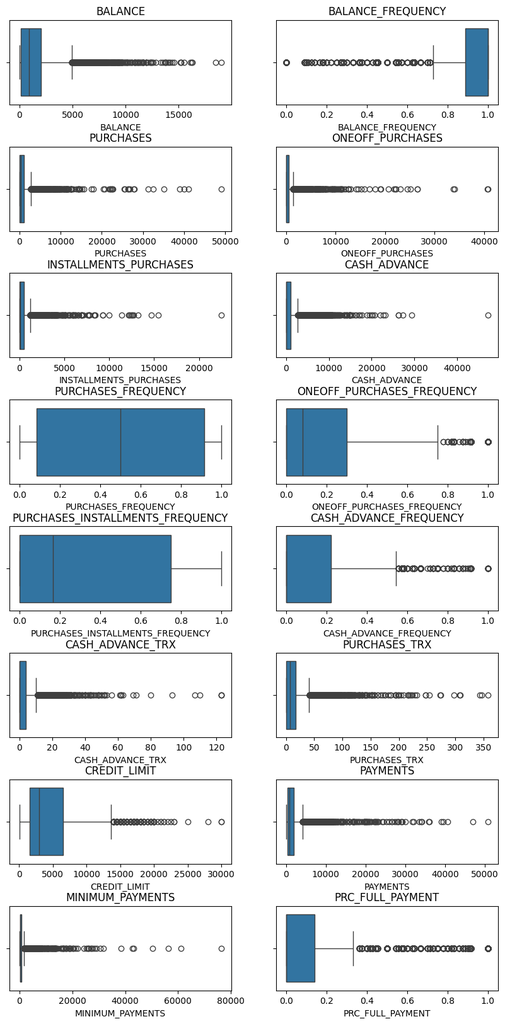

```python
i = 1
plt.figure(figsize=(10, 20))
for column in df.columns.to_list()[1:-1]:
    plt.subplot(8, 2, i)
    i += 1
    sns.boxplot(x=df[column])
    plt.title(column)
plt.subplots_adjust(hspace=0.5)
plt.show()
```

there are too many outliers in the dataset

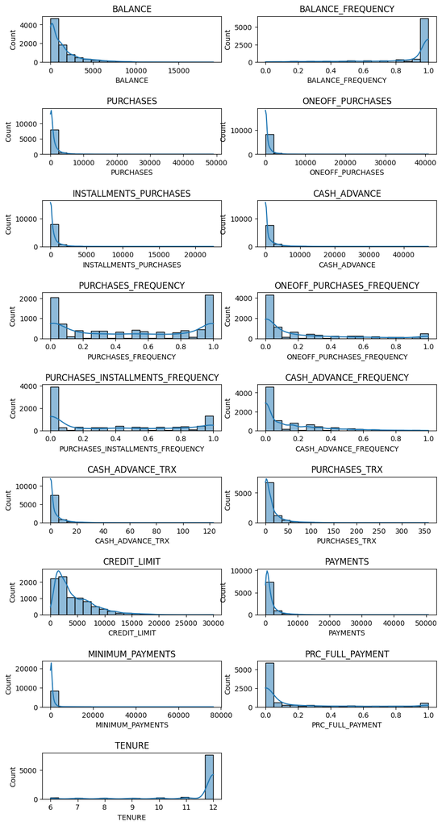

```python
i = 1
plt.figure(figsize=(10, 20))
for column in df.columns.to_list()[1:]:
    plt.subplot(9, 2, i)
    i += 1
    sns.histplot(df[column], kde=True, bins=20)
    plt.title(column)
plt.subplots_adjust(hspace=1)
plt.show()
```

the data is very skewed

```python
df['MINIMUM_PAYMENTS'].value_counts()
```

```
299.351881    2
342.286490    1
184.464721    1
276.486072    1
309.140865    1
             ..
452.084802    1
181.773223    1
711.894455    1
256.522546    1
88.288956     1
Name: MINIMUM_PAYMENTS, Length: 8628, dtype: int64
```

no not categoric!

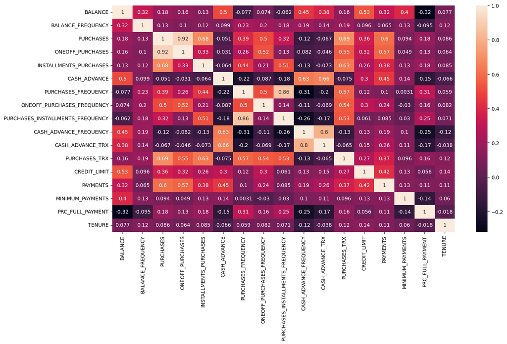

```python
fig = plt.figure(figsize = (15, 8))
sns.heatmap(df.iloc[:,1:].corr() , annot=True)
```

there are highly corelated columns could means they are redundent or they are just related

## 3. Data preprocessing

(Go to top)

### Define below all the issues that you had found in the previous part

0- drop id column  
1- null values  
2- redundent columns  
3- outliers

```python
#make a copy for the original dataset
df_copy=df.copy()
```

### for each issue adapt this methodology

- start by defining the solution
- apply this solution onn the data
- test the solution to make sure that you have solved the issue

```python
df.drop('CUST_ID', axis=1, inplace=True)
```

```python
df.shape
```

```
(8942, 17)
```

**First issue**

the coulmns that have null values:

1 - CREDIT_LIMIT --- very small portion can be droped  
2 - MINIMUM_PAYMENTS -- can be relaced with mean

```python
#solution
df.dropna(subset=['CREDIT_LIMIT'], inplace= True)
df['MINIMUM_PAYMENTS'].replace(np.NaN,df['MINIMUM_PAYMENTS'].mean(), inplace=True)
```

```python
df.shape
```

```
(8941, 17)
```

```python
#test
df.isna().sum()
```

```
BALANCE                             0
BALANCE_FREQUENCY                   0
PURCHASES                           0
ONEOFF_PURCHASES                    0
INSTALLMENTS_PURCHASES              0
CASH_ADVANCE                        0
PURCHASES_FREQUENCY                 0
ONEOFF_PURCHASES_FREQUENCY          0
PURCHASES_INSTALLMENTS_FREQUENCY    0
CASH_ADVANCE_FREQUENCY              0
CASH_ADVANCE_TRX                    0
PURCHASES_TRX                       0
CREDIT_LIMIT                        0
PAYMENTS                            0
MINIMUM_PAYMENTS                    0
PRC_FULL_PAYMENT                    0
TENURE                              0
dtype: int64
```

**Second issue**

```python
df.corr()
```

|  | BALANCE | BALANCE_FREQUENCY | PURCHASES | ONEOFF_PURCHASES | INSTALLMENTS_PURCHASES | CASH_ADVANCE | PURCHASES_FREQUENCY | ONEOFF_PURCHASES_FREQUENCY | PURCHASES_INSTALLMENTS_FREQUENCY | CASH_ADVANCE_FREQUENCY | CASH_ADVANCE_TRX | PURCHASES_TRX | CREDIT_LIMIT | PAYMENTS | MINIMUM_PAYMENTS | PRC_FULL_PAYMENT | TENURE |
| --- | --- | --- | --- | --- | --- | --- | --- | --- | --- | --- | --- | --- | --- | --- | --- | --- | --- |
| BALANCE | 1.000000 | 0.322262 | 0.182023 | 0.164910 | 0.127231 | 0.496218 | -0.076911 | 0.073639 | -0.062139 | 0.448506 | 0.384113 | 0.155234 | 0.530764 | 0.323616 | 0.394599 | -0.318777 | 0.076570 |
| BALANCE_FREQUENCY | 0.322262 | 1.000000 | 0.133759 | 0.104368 | 0.124403 | 0.098899 | 0.229854 | 0.202373 | 0.176307 | 0.192453 | 0.140939 | 0.189763 | 0.095633 | 0.064888 | 0.114189 | -0.095128 | 0.120084 |
| PURCHASES | 0.182023 | 0.133759 | 1.000000 | 0.916843 | 0.679838 | -0.051134 | 0.392848 | 0.498420 | 0.315350 | -0.119765 | -0.066567 | 0.689498 | 0.357410 | 0.603330 | 0.093521 | 0.180203 | 0.085472 |
| ONEOFF_PURCHASES | 0.164910 | 0.104368 | 0.916843 | 1.000000 | 0.330542 | -0.031121 | 0.264798 | 0.524890 | 0.127531 | -0.082391 | -0.045809 | 0.545472 | 0.320053 | 0.567342 | 0.048592 | 0.132640 | 0.063583 |
| INSTALLMENTS_PURCHASES | 0.127231 | 0.124403 | 0.679838 | 0.330542 | 1.000000 | -0.063813 | 0.442260 | 0.213984 | 0.511201 | -0.131856 | -0.073299 | 0.628022 | 0.256931 | 0.384109 | 0.131710 | 0.182373 | 0.085249 |
| CASH_ADVANCE | 0.496218 | 0.098899 | -0.051134 | -0.031121 | -0.063813 | 1.000000 | -0.215110 | -0.086949 | -0.176315 | 0.631235 | 0.656286 | -0.075410 | 0.303772 | 0.453735 | 0.139205 | -0.152540 | -0.066227 |
| PURCHASES_FREQUENCY | -0.076911 | 0.229854 | 0.392848 | 0.264798 | 0.442260 | -0.215110 | 1.000000 | 0.501263 | 0.862874 | -0.308412 | -0.202537 | 0.568280 | 0.120485 | 0.103251 | 0.002972 | 0.305513 | 0.058934 |
| ONEOFF_PURCHASES_FREQUENCY | 0.073639 | 0.202373 | 0.498420 | 0.524890 | 0.213984 | -0.086949 | 0.501263 | 1.000000 | 0.142186 | -0.112171 | -0.069078 | 0.544866 | 0.295453 | 0.243416 | -0.029986 | 0.157447 | 0.081870 |
| PURCHASES_INSTALLMENTS_FREQUENCY | -0.062139 | 0.176307 | 0.315350 | 0.127531 | 0.511201 | -0.176315 | 0.862874 | 0.142186 | 1.000000 | -0.262057 | -0.167905 | 0.529789 | 0.061352 | 0.085434 | 0.029614 | 0.249743 | 0.070949 |
| CASH_ADVANCE_FREQUENCY | 0.448506 | 0.192453 | -0.119765 | -0.082391 | -0.131856 | 0.631235 | -0.308412 | -0.112171 | -0.262057 | 1.000000 | 0.801319 | -0.130375 | 0.131339 | 0.186360 | 0.098908 | -0.250508 | -0.121781 |
| CASH_ADVANCE_TRX | 0.384113 | 0.140939 | -0.066567 | -0.045809 | -0.073299 | 0.656286 | -0.202537 | -0.069078 | -0.167905 | 0.801319 | 1.000000 | -0.065344 | 0.149194 | 0.256015 | 0.109480 | -0.169219 | -0.038545 |
| PURCHASES_TRX | 0.155234 | 0.189763 | 0.689498 | 0.545472 | 0.628022 | -0.075410 | 0.568280 | 0.544866 | 0.529789 | -0.130375 | -0.065344 | 1.000000 | 0.273371 | 0.370816 | 0.095878 | 0.161834 | 0.120879 |
| CREDIT_LIMIT | 0.530764 | 0.095633 | 0.357410 | 0.320053 | 0.256931 | 0.303772 | 0.120485 | 0.295453 | 0.061352 | 0.131339 | 0.149194 | 0.273371 | 1.000000 | 0.422353 | 0.125060 | 0.056019 | 0.141206 |
| PAYMENTS | 0.323616 | 0.064888 | 0.603330 | 0.567342 | 0.384109 | 0.453735 | 0.103251 | 0.243416 | 0.085434 | 0.186360 | 0.256015 | 0.370816 | 0.422353 | 1.000000 | 0.125080 | 0.112077 | 0.105539 |
| MINIMUM_PAYMENTS | 0.394599 | 0.114189 | 0.093521 | 0.048592 | 0.131710 | 0.139205 | 0.002972 | -0.029986 | 0.029614 | 0.098908 | 0.109480 | 0.095878 | 0.125060 | 0.125080 | 1.000000 | -0.139692 | 0.057495 |
| PRC_FULL_PAYMENT | -0.318777 | -0.095128 | 0.180203 | 0.132640 | 0.182373 | -0.152540 | 0.305513 | 0.157447 | 0.249743 | -0.250508 | -0.169219 | 0.161834 | 0.056019 | 0.112077 | -0.139692 | 1.000000 | -0.018151 |
| TENURE | 0.076570 | 0.120084 | 0.085472 | 0.063583 | 0.085249 | -0.066227 | 0.058934 | 0.081870 | 0.070949 | -0.121781 | -0.038545 | 0.120879 | 0.141206 | 0.105539 | 0.057495 | -0.018151 | 1.000000 |

looking at corr > 80%

- ONEOFF_PURCHASES is highly correlated with PURCHASES but it must be so not going to drop
- PURCHASES_INSTALLMENTS_FREQUENCY is highly correlated with PURCHASES_FREQUENCY but it must be so not going to drop
- CASH_ADVANCE_FREQUENCY is highly correlated with CASH_ADVANCE_TRX and i see it is redundent can only keep CASH_ADVANCE_FREQUENCY

```python
#solution
df.drop('CASH_ADVANCE_TRX', axis=1, inplace=True)
```

**Third issue**

```python
df.shape
```

```
(8941, 16)
```

```python
#solution
#the data is right skewed so can try log transform on features that are not scaled
open_limits_features = ['BALANCE',
                          'PURCHASES',
                          'ONEOFF_PURCHASES',
                          'INSTALLMENTS_PURCHASES',
                          'CASH_ADVANCE', 'CREDIT_LIMIT',
                          'PAYMENTS',
                          'MINIMUM_PAYMENTS',
                          'PURCHASES_TRX'
                          ]
bounded_limits_features = ['BALANCE_FREQUENCY',
                      'PURCHASES_FREQUENCY',
                      'ONEOFF_PURCHASES_FREQUENCY',
                      'PURCHASES_INSTALLMENTS_FREQUENCY',
                      'CASH_ADVANCE_FREQUENCY',
                      'PRC_FULL_PAYMENT',
                      'TENURE' ]
log_scaled_data = np.log1p(df[open_limits_features])
log_scaled_data[bounded_limits_features] = df[bounded_limits_features]
log_scaled_data.head()
```

|  | BALANCE | PURCHASES | ONEOFF_PURCHASES | INSTALLMENTS_PURCHASES | CASH_ADVANCE | CREDIT_LIMIT | PAYMENTS | MINIMUM_PAYMENTS | PURCHASES_TRX | BALANCE_FREQUENCY | PURCHASES_FREQUENCY | ONEOFF_PURCHASES_FREQUENCY | PURCHASES_INSTALLMENTS_FREQUENCY | CASH_ADVANCE_FREQUENCY | PRC_FULL_PAYMENT | TENURE |
| --- | --- | --- | --- | --- | --- | --- | --- | --- | --- | --- | --- | --- | --- | --- | --- | --- |
| 0 | 3.735304 | 4.568506 | 0.000000 | 4.568506 | 0.000000 | 6.908755 | 5.312231 | 4.945277 | 1.098612 | 0.818182 | 0.166667 | 0.000000 | 0.083333 | 0.000000 | 0.000000 | 12 |
| 1 | 8.071989 | 0.000000 | 0.000000 | 0.000000 | 8.770896 | 8.853808 | 8.319725 | 6.978531 | 0.000000 | 0.909091 | 0.000000 | 0.000000 | 0.000000 | 0.250000 | 0.222222 | 12 |
| 2 | 7.822504 | 6.651791 | 6.651791 | 0.000000 | 0.000000 | 8.922792 | 6.434654 | 6.442994 | 2.564949 | 1.000000 | 1.000000 | 1.000000 | 0.000000 | 0.000000 | 0.000000 | 12 |
| 3 | 7.419183 | 7.313220 | 7.313220 | 0.000000 | 5.331694 | 8.922792 | 0.000000 | 6.762937 | 0.693147 | 0.636364 | 0.083333 | 0.083333 | 0.000000 | 0.083333 | 0.000000 | 12 |
| 4 | 6.707735 | 2.833213 | 2.833213 | 0.000000 | 0.000000 | 7.090910 | 6.521114 | 5.504483 | 0.693147 | 1.000000 | 0.083333 | 0.083333 | 0.000000 | 0.000000 | 0.000000 | 12 |

```python
log_scaled_data.shape
```

```
(8941, 16)
```

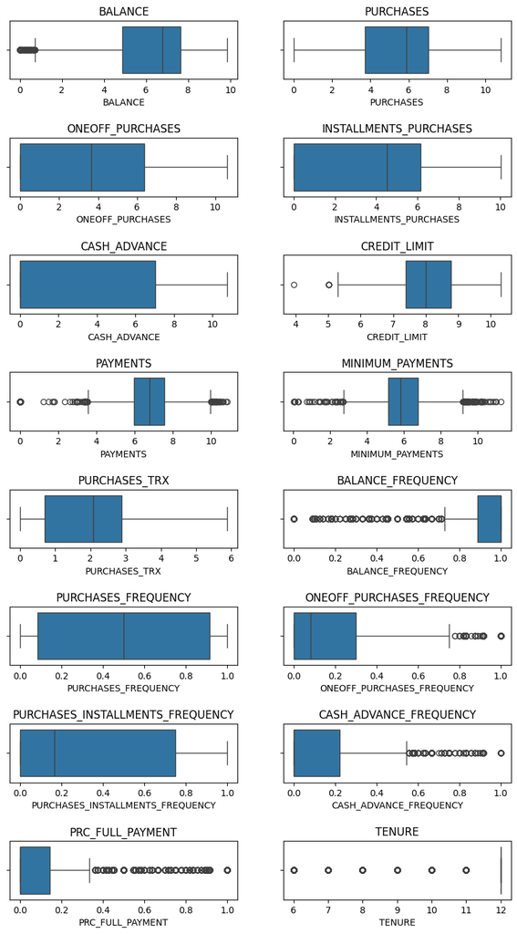

```python
#test
i = 1
plt.figure(figsize=(10, 20))
for column in log_scaled_data.columns.to_list():
    plt.subplot(9, 2, i)
    i += 1
    sns.boxplot(x=log_scaled_data[column])
    plt.title(column)
plt.subplots_adjust(hspace=1)
plt.show()
```

```python
# for column in df.columns.to_list()[:-1]:
#     bins = np.linspace(df[column].min(),df[column].max(),endpoint= True,num=20)
#     df[column] = pd.cut(df[column], bins, labels= np.arange(1,20,).tolist(), include_lowest = True)
```

```python
# df = df.astype(int)
```

```python
# df.head()
```

```python
# df.info()
```

```python
# i = 1
# plt.figure(figsize=(10, 20))
# for column in df.columns.to_list():
#     plt.subplot(9, 2, i)
#     i += 1
#     sns.boxplot(x=df[column])
#     plt.title(column)
# plt.subplots_adjust(hspace=1)
# plt.show()
```

## 4. Features transformation

(Go to top)

*What is the feature scaling technique that would use and why?*  
*return to this section again and try another technique and see how that will impact your result*  
for more details on different methods for scaling check these links

- https://scikit-learn.org/stable/modules/preprocessing.html#preprocessing
- https://scikit-learn.org/stable/modules/classes.html#module-sklearn.preprocessing
- https://www.analyticsvidhya.com/blog/2020/07/types-of-feature-transformation-and-scaling/

Answer here:

```python
from sklearn.preprocessing import StandardScaler
```

```python
scale = StandardScaler()
df_scaled = scale.fit_transform(df)
df_scaled_df = pd.DataFrame(data = df_scaled, columns = df.columns)
```

```python
df_scaled.shape
```

```
(8941, 16)
```

```python
df_scaled_df.head()
```

|  | BALANCE | BALANCE_FREQUENCY | PURCHASES | ONEOFF_PURCHASES | INSTALLMENTS_PURCHASES | CASH_ADVANCE | PURCHASES_FREQUENCY | ONEOFF_PURCHASES_FREQUENCY | PURCHASES_INSTALLMENTS_FREQUENCY | CASH_ADVANCE_FREQUENCY | PURCHASES_TRX | CREDIT_LIMIT | PAYMENTS | MINIMUM_PAYMENTS | PRC_FULL_PAYMENT | TENURE |
| --- | --- | --- | --- | --- | --- | --- | --- | --- | --- | --- | --- | --- | --- | --- | --- | --- |
| 0 | -0.731363 | -0.249412 | -0.425134 | -0.357050 | -0.349397 | -0.465958 | -0.807365 | -0.678659 | -0.708180 | -0.678923 | -0.511676 | -0.959889 | -0.528992 | -3.108095e-01 | -0.525889 | 0.359427 |
| 1 | 0.788911 | 0.134388 | -0.469767 | -0.357050 | -0.454852 | 2.608374 | -1.222618 | -0.678659 | -0.917845 | 0.585890 | -0.592110 | 0.689259 | 0.818192 | 8.927972e-02 | 0.233613 | 0.359427 |
| 2 | 0.448789 | 0.518189 | -0.108034 | 0.108558 | -0.454852 | -0.465958 | 1.268895 | 2.672242 | -0.917845 | -0.678923 | -0.109509 | 0.826688 | -0.383865 | -1.016037e-01 | -0.525889 | 0.359427 |
| 3 | 0.050406 | -1.017012 | 0.231550 | 0.545658 | -0.454852 | -0.367764 | -1.014993 | -0.399419 | -0.917845 | -0.257320 | -0.551893 | 0.826688 | -0.598678 | -4.876007e-17 | -0.525889 | 0.359427 |
| 4 | -0.357824 | 0.518189 | -0.462281 | -0.347414 | -0.454852 | -0.465958 | -1.014993 | -0.399419 | -0.917845 | -0.678923 | -0.551893 | -0.904917 | -0.364434 | -2.656545e-01 | -0.525889 | 0.359427 |

## 5. K Means

(Go to top)

1- Use the k means class that you implemented in the previous task to cluster this data 2- Use http://scikit-learn.org/stable/modules/generated/sklearn.cluster.KMeans.html and see if the difference in the result 3- Use elbow method to determine the K (plot the result using two plot one for distorion and another for inertia) 4- (Optionally) make a method that pick the best number of clusters for you 5- Using different techniques for scaling and comment on the result

```python
from sklearn.cluster import KMeans
```

```python
n_clusters=20
cost=[]
for i in range(1,n_clusters):
    kmean= KMeans(i)
    kmean.fit(log_scaled_data)
    cost.append(kmean.inertia_)
```

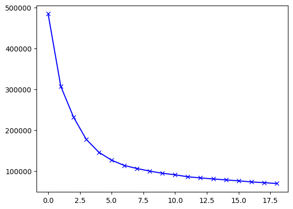

```python
plt.plot(cost, 'bx-')
```

k = 5

```python
k_means = KMeans(
    n_clusters = 5,
    random_state = 42
)

k_means.fit(log_scaled_data)
```

```
KMeans(n_clusters=5, random_state=42)
```

```python
labels=k_means.labels_
```

```python
labels
```

```
array([4, 0, 1, ..., 4, 0, 1], dtype=int32)
```

```python
clusters=pd.concat([df, pd.DataFrame({'cluster':labels})], axis=1)
clusters.head()
```

|  | BALANCE | BALANCE_FREQUENCY | PURCHASES | ONEOFF_PURCHASES | INSTALLMENTS_PURCHASES | CASH_ADVANCE | PURCHASES_FREQUENCY | ONEOFF_PURCHASES_FREQUENCY | PURCHASES_INSTALLMENTS_FREQUENCY | CASH_ADVANCE_FREQUENCY | PURCHASES_TRX | CREDIT_LIMIT | PAYMENTS | MINIMUM_PAYMENTS | PRC_FULL_PAYMENT | TENURE | cluster |
| --- | --- | --- | --- | --- | --- | --- | --- | --- | --- | --- | --- | --- | --- | --- | --- | --- | --- |
| 0 | 40.900749 | 0.818182 | 95.40 | 0.00 | 95.4 | 0.000000 | 0.166667 | 0.000000 | 0.083333 | 0.000000 | 2.0 | 1000.0 | 201.802084 | 139.509787 | 0.000000 | 12.0 | 4.0 |
| 1 | 3202.467416 | 0.909091 | 0.00 | 0.00 | 0.0 | 6442.945483 | 0.000000 | 0.000000 | 0.000000 | 0.250000 | 0.0 | 7000.0 | 4103.032597 | 1072.340217 | 0.222222 | 12.0 | 0.0 |
| 2 | 2495.148862 | 1.000000 | 773.17 | 773.17 | 0.0 | 0.000000 | 1.000000 | 1.000000 | 0.000000 | 0.000000 | 12.0 | 7500.0 | 622.066742 | 627.284787 | 0.000000 | 12.0 | 1.0 |
| 3 | 1666.670542 | 0.636364 | 1499.00 | 1499.00 | 0.0 | 205.788017 | 0.083333 | 0.083333 | 0.000000 | 0.083333 | 1.0 | 7500.0 | 0.000000 | 864.179560 | 0.000000 | 12.0 | 1.0 |
| 4 | 817.714335 | 1.000000 | 16.00 | 16.00 | 0.0 | 0.000000 | 0.083333 | 0.083333 | 0.000000 | 0.000000 | 1.0 | 1200.0 | 678.334763 | 244.791237 | 0.000000 | 12.0 | 1.0 |

```python
from sklearn.metrics import silhouette_score
silhouette_score(log_scaled_data, k_means.fit_predict(log_scaled_data))
```

```
0.4016307225670072
```

k = 6

```python
k_means = KMeans(
    n_clusters = 6,
    random_state = 42
)

k_means.fit(log_scaled_data)
```

```
KMeans(n_clusters=6, random_state=42)
```

```python
labels=k_means.labels_
```

```python
clusters_1=pd.concat([df, pd.DataFrame({'cluster':labels})], axis=1)
clusters_1.head()
```

|  | BALANCE | BALANCE_FREQUENCY | PURCHASES | ONEOFF_PURCHASES | INSTALLMENTS_PURCHASES | CASH_ADVANCE | PURCHASES_FREQUENCY | ONEOFF_PURCHASES_FREQUENCY | PURCHASES_INSTALLMENTS_FREQUENCY | CASH_ADVANCE_FREQUENCY | PURCHASES_TRX | CREDIT_LIMIT | PAYMENTS | MINIMUM_PAYMENTS | PRC_FULL_PAYMENT | TENURE | cluster |
| --- | --- | --- | --- | --- | --- | --- | --- | --- | --- | --- | --- | --- | --- | --- | --- | --- | --- |
| 0 | 40.900749 | 0.818182 | 95.40 | 0.00 | 95.4 | 0.000000 | 0.166667 | 0.000000 | 0.083333 | 0.000000 | 2.0 | 1000.0 | 201.802084 | 139.509787 | 0.000000 | 12.0 | 3.0 |
| 1 | 3202.467416 | 0.909091 | 0.00 | 0.00 | 0.0 | 6442.945483 | 0.000000 | 0.000000 | 0.000000 | 0.250000 | 0.0 | 7000.0 | 4103.032597 | 1072.340217 | 0.222222 | 12.0 | 2.0 |
| 2 | 2495.148862 | 1.000000 | 773.17 | 773.17 | 0.0 | 0.000000 | 1.000000 | 1.000000 | 0.000000 | 0.000000 | 12.0 | 7500.0 | 622.066742 | 627.284787 | 0.000000 | 12.0 | 5.0 |
| 3 | 1666.670542 | 0.636364 | 1499.00 | 1499.00 | 0.0 | 205.788017 | 0.083333 | 0.083333 | 0.000000 | 0.083333 | 1.0 | 7500.0 | 0.000000 | 864.179560 | 0.000000 | 12.0 | 4.0 |
| 4 | 817.714335 | 1.000000 | 16.00 | 16.00 | 0.0 | 0.000000 | 0.083333 | 0.083333 | 0.000000 | 0.000000 | 1.0 | 1200.0 | 678.334763 | 244.791237 | 0.000000 | 12.0 | 5.0 |

```python
silhouette_score(log_scaled_data, k_means.fit_predict(log_scaled_data))
```

```
0.41432008275504206
```

higher silhouette_score at k = 6

```python
%matplotlib inline
```

**t-SNE**

```python
from sklearn.manifold import TSNE
import plotly.express as px
```

```python
# Apply t-SNE to reduce the dimensionality to 2
tsne = TSNE(
    n_components=2,
    random_state=42
)
tsne_result_2d = tsne.fit_transform(log_scaled_data)
```

```python
tsne_result_2d
```

```
array([[ 12.182074  , -46.25474   ],
       [-73.18294   ,   0.72961396],
       [  5.8154354 ,  23.232464  ],
       ...,
       [ -4.212592  , -32.485382  ],
       [-59.677605  , -39.896534  ],
       [-16.571835  ,  77.09433   ]], dtype=float32)
```

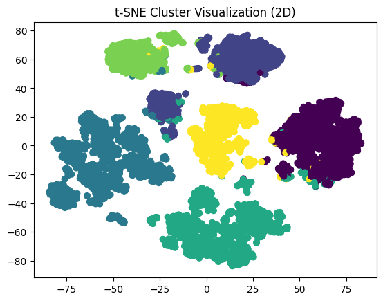

```python
# Visualizing t-SNE reduction
plt.scatter(tsne_result_2d[:, 0], tsne_result_2d[:, 1], c=labels)
plt.title("t-SNE Cluster Visualization (2D)")
plt.show()
```

looking at t-SNE seems like there are 7 clusters not 6

```python
k_means = KMeans(
    n_clusters = 7,
    random_state = 42
)

k_means.fit(log_scaled_data)
```

```
KMeans(n_clusters=7, random_state=42)
```

```python
labels=k_means.labels_
```

```python
clusters=pd.concat([df, pd.DataFrame({'cluster':labels})], axis=1)
clusters.head()
```

|  | BALANCE | BALANCE_FREQUENCY | PURCHASES | ONEOFF_PURCHASES | INSTALLMENTS_PURCHASES | CASH_ADVANCE | PURCHASES_FREQUENCY | ONEOFF_PURCHASES_FREQUENCY | PURCHASES_INSTALLMENTS_FREQUENCY | CASH_ADVANCE_FREQUENCY | PURCHASES_TRX | CREDIT_LIMIT | PAYMENTS | MINIMUM_PAYMENTS | PRC_FULL_PAYMENT | TENURE | cluster |
| --- | --- | --- | --- | --- | --- | --- | --- | --- | --- | --- | --- | --- | --- | --- | --- | --- | --- |
| 0 | 40.900749 | 0.818182 | 95.40 | 0.00 | 95.4 | 0.000000 | 0.166667 | 0.000000 | 0.083333 | 0.000000 | 2.0 | 1000.0 | 201.802084 | 139.509787 | 0.000000 | 12.0 | 4.0 |
| 1 | 3202.467416 | 0.909091 | 0.00 | 0.00 | 0.0 | 6442.945483 | 0.000000 | 0.000000 | 0.000000 | 0.250000 | 0.0 | 7000.0 | 4103.032597 | 1072.340217 | 0.222222 | 12.0 | 2.0 |
| 2 | 2495.148862 | 1.000000 | 773.17 | 773.17 | 0.0 | 0.000000 | 1.000000 | 1.000000 | 0.000000 | 0.000000 | 12.0 | 7500.0 | 622.066742 | 627.284787 | 0.000000 | 12.0 | 1.0 |
| 3 | 1666.670542 | 0.636364 | 1499.00 | 1499.00 | 0.0 | 205.788017 | 0.083333 | 0.083333 | 0.000000 | 0.083333 | 1.0 | 7500.0 | 0.000000 | 864.179560 | 0.000000 | 12.0 | 5.0 |
| 4 | 817.714335 | 1.000000 | 16.00 | 16.00 | 0.0 | 0.000000 | 0.083333 | 0.083333 | 0.000000 | 0.000000 | 1.0 | 1200.0 | 678.334763 | 244.791237 | 0.000000 | 12.0 | 1.0 |

```python
silhouette_score(log_scaled_data, k_means.fit_predict(log_scaled_data))
```

```
0.4309447328097192
```

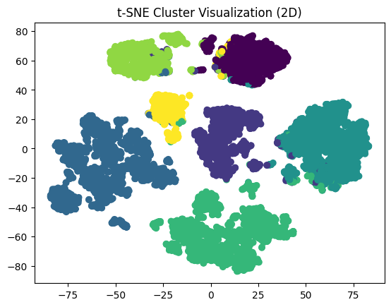

```python
# Visualizing t-SNE reduction
plt.scatter(tsne_result_2d[:, 0], tsne_result_2d[:, 1], c=labels)
plt.title("t-SNE Cluster Visualization (2D)")
plt.show()
```

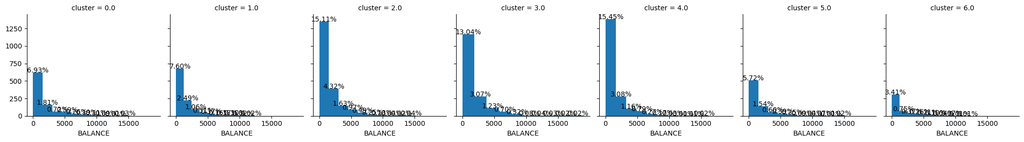

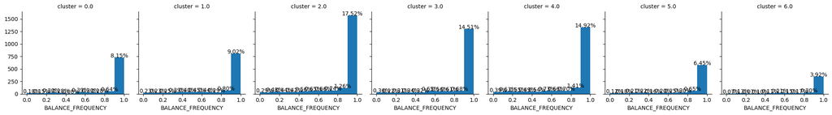

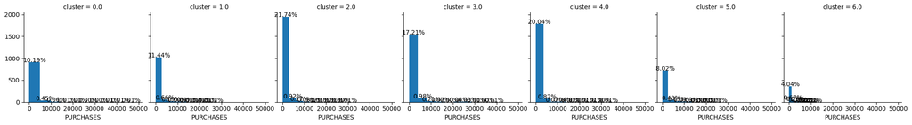

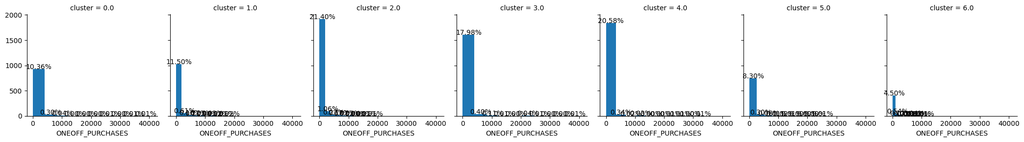

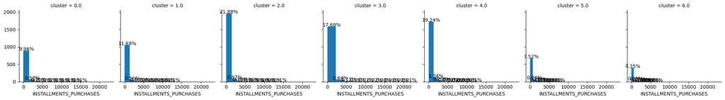

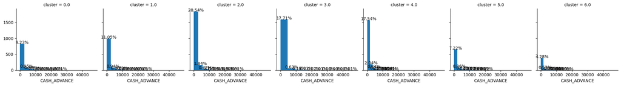

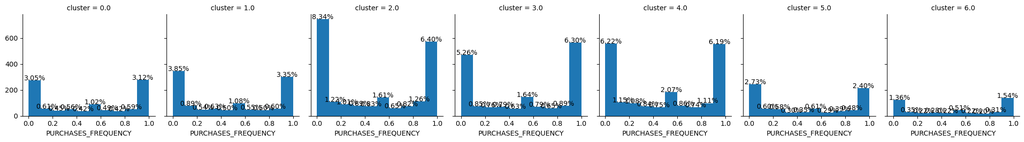

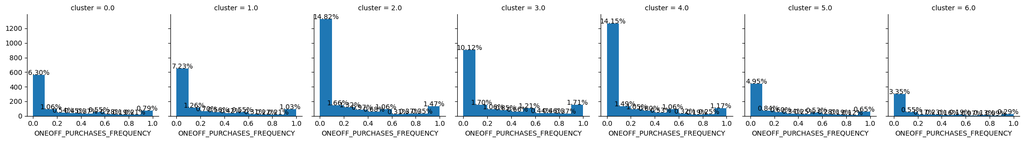

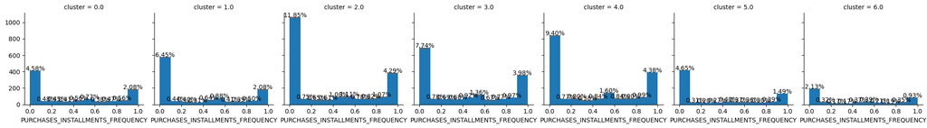

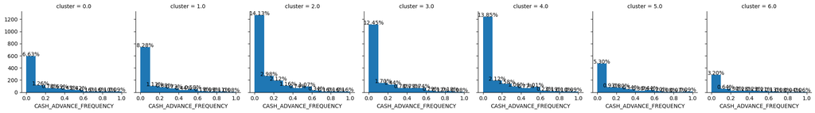

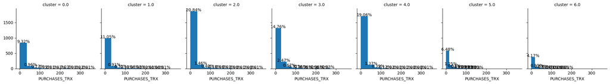

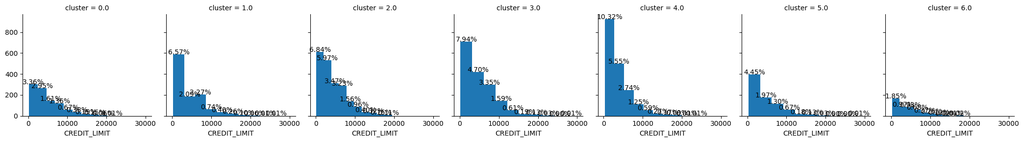

[4 more figures not shown]

```python
for feature in clusters_1.columns:  # Iterate over columns in clusters_1
    if feature != 'cluster':  # Exclude the 'cluster' column from plotting
        grid = sns.FacetGrid(clusters, col='cluster')
        grid.map(plt.hist, feature)

        # Add percentage annotations
        for ax in grid.axes.flat:
            for patch in ax.patches:
                height = patch.get_height()
                ax.text(
                    patch.get_x() + patch.get_width() / 2, height + 0.05,
                    f'{(height / len(clusters)) * 100:.2f}%',
                    ha='center'
                )

plt.show()
```

- **Cluster0** People with low payments
- **Cluster1** This group has more people with average credit limit and their balance and payments are also average
- **Cluster2** Less money spenders with low credit limits who purchases mostly in installments
- **Cluster3** People with lots of purshases and do more installments
- **Cluster4** people who pay cash in advance frequently
- **Cluster5** average customers in payments and balance
- **Cluster6** minimum customers customers in payments and balance

**PCA**

```python
from sklearn.decomposition import PCA
```

```python
# Reduce dimensionality using PCA
pca = PCA(n_components=2)
PCA_result_2d = pca.fit_transform(log_scaled_data)
pca.explained_variance_ratio_
```

```
array([0.47075993, 0.22980712])
```

```python
PCA_result_2d
```

```
array([[ 0.78524132, -5.59571813],
       [-8.88953027,  1.80101655],
       [ 2.55744059,  1.51531054],
       ...,
       [ 1.25695631, -6.16334311],
       [-6.02528382, -5.3762036 ],
       [ 0.40815603,  2.68405935]])
```

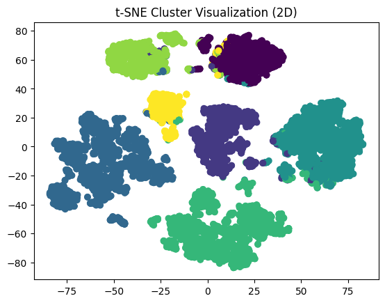

```python
# Visualizing t-SNE reduction
plt.scatter(tsne_result_2d[:, 0], tsne_result_2d[:, 1], c=labels)
plt.title("t-SNE Cluster Visualization (2D)")
plt.show()
```

## 6. Training and hyperparamter tuning

(Go to top)

Before we start the training process we need to specify 3 paramters:  
1- Linkage criteria : The linkage criterion determines the distance between two clusters

```
- Complete-Linkage Clustering
- Single-Linkage Clustering
- Average-Linkage Clustering
- Centroid Linkage Clustering
```

2- Distance function:

```
- Euclidean Distance
- Manhattan Distance
- Mahalanobis distance
```

3- Number of clusters

### *Number of clusters*

Use Dendograms to specify the optimum number of clusters

- Compare how changing linkage criteria or distance function would affect the optimum number of clusters
- you can use silhouette_score or any other evalution method to help you determine the optimum number of clusters https://scikit-learn.org/stable/modules/generated/sklearn.metrics.silhouette_score.html

```python
from scipy.cluster.hierarchy import dendrogram, linkage
```

```python
distance_metrics = ['euclidean', 'cityblock', 'mahalanobis']
```

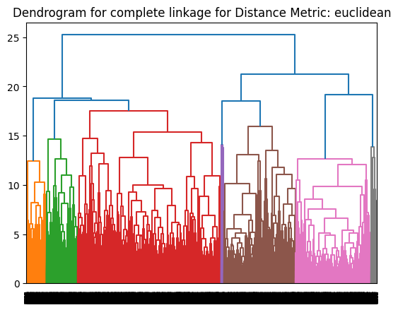

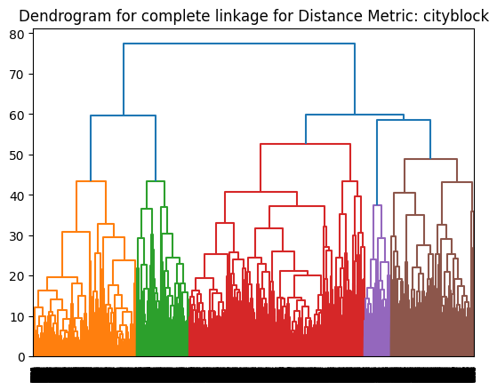

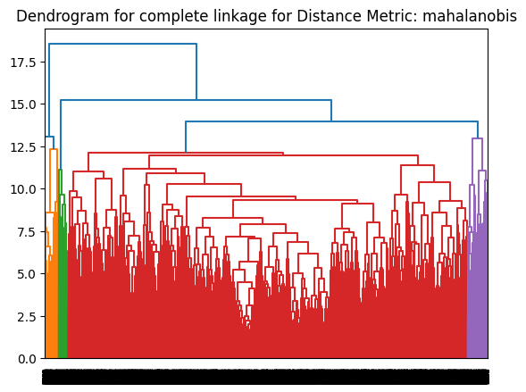

```python
link = 'complete'
for dist in distance_metrics:
  link_mat = linkage(log_scaled_data,method= link, metric= dist)
  dendrogram(link_mat)
  plt.title(f'Dendrogram for complete linkage for Distance Metric: {dist}')
  plt.show()
```

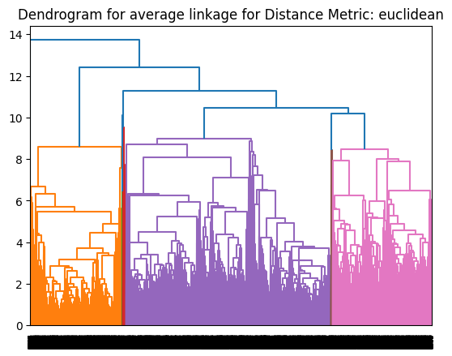

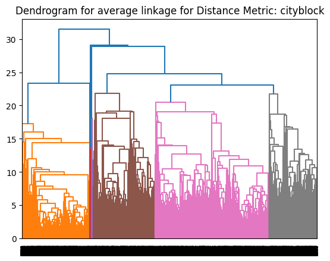

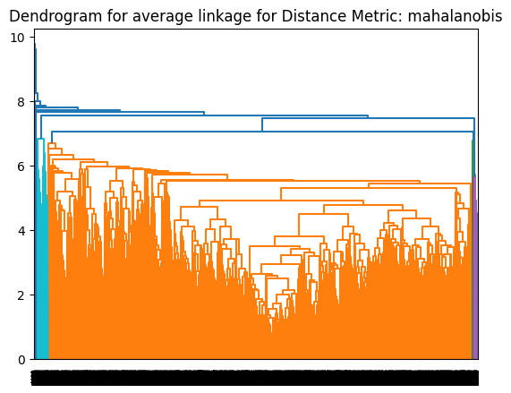

```python
link = 'average'
for dist in distance_metrics:
  link_mat = linkage(log_scaled_data,method= link, metric= dist)
  dendrogram(link_mat)
  plt.title(f'Dendrogram for average linkage for Distance Metric: {dist}')
  plt.show()
```

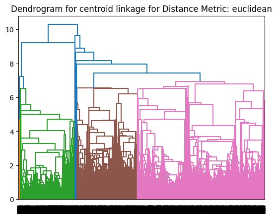

```python
link_mat = linkage(log_scaled_data,method='centroid', metric='euclidean')
dendrogram(link_mat)
plt.title(f'Dendrogram for centroid linkage for Distance Metric: euclidean')
plt.show()
```

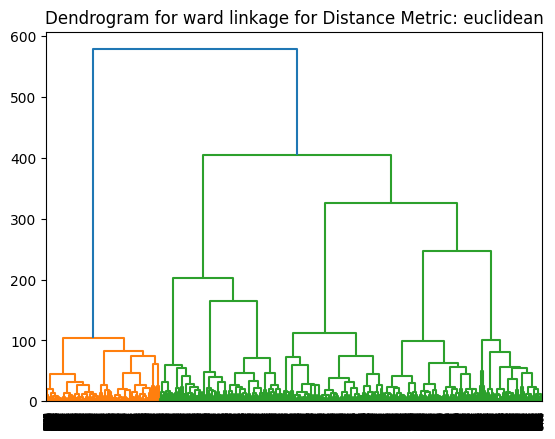

```python
link_mat = linkage(log_scaled_data,method='ward', metric='euclidean')
dendrogram(link_mat)
plt.title(f'Dendrogram for ward linkage for Distance Metric: euclidean')
plt.show()
```

decided to choose ward with euclidean distance and cut to have 7 clusters

```python
from sklearn.cluster import AgglomerativeClustering

clustering = AgglomerativeClustering(n_clusters=7,linkage='ward', affinity='euclidean').fit(log_scaled_data)
labels = clustering.labels_
```

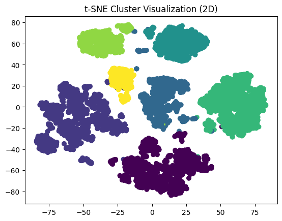

```python
# Visualizing t-SNE reduction
plt.scatter(tsne_result_2d[:, 0], tsne_result_2d[:, 1], c=labels)
plt.title("t-SNE Cluster Visualization (2D)")
plt.show()
```

### DBSCAN

with grid search

```python
from sklearn.cluster import DBSCAN
```

```python
epsilons = np.linspace(1, 10, num=8)
epsilons
```

```
array([ 1.        ,  2.28571429,  3.57142857,  4.85714286,  6.14285714,
        7.42857143,  8.71428571, 10.        ])
```

```python
min_samples = np.arange(100, 800, step=50)
min_samples
```

```
array([100, 150, 200, 250, 300, 350, 400, 450, 500, 550, 600, 650, 700,
       750])
```

```python
import itertools

combinations = list(itertools.product(epsilons, min_samples))
combinations
```

[output not shown]

[output cut: 57 more lines]

[output not shown]

```python
N = len(combinations)
```

```python
N
```

```
112
```

```python
def get_scores_and_labels(combinations, X):
  scores = []
  all_labels_list = []

  for i, (eps, num_samples) in enumerate(combinations):
    dbscan_cluster_model = DBSCAN(eps=eps, min_samples=num_samples).fit(log_scaled_data)
    labels = dbscan_cluster_model.labels_
    labels_set = set(labels)
    num_clusters = len(labels_set)
    if -1 in labels_set:
      num_clusters -= 1

    if (num_clusters < 2) or (num_clusters > 10):
      scores.append(-10)
      all_labels_list.append('bad')
      c = (eps, num_samples)
      print(f"Combination {c} on iteration {i+1} of {N} has {num_clusters} clusters. Moving on")
      continue

    scores.append(silhouette_score(log_scaled_data, labels))
    all_labels_list.append(labels)
    print(f"Index: {i}, Score: {scores[-1]}, Labels: {all_labels_list[-1]}, NumClusters: {num_clusters}")

  best_index = np.argmax(scores)
  best_parameters = combinations[best_index]
  best_labels = all_labels_list[best_index]
  best_score = scores[best_index]

  return {'best_epsilon': best_parameters[0],
          'best_min_samples': best_parameters[1],
          'best_labels': best_labels,
          'best_score': best_score}

best_dict = get_scores_and_labels(combinations, log_scaled_data)
```

```
Combination (1.0, 100) on iteration 1 of 112 has 1 clusters. Moving on
Combination (1.0, 150) on iteration 2 of 112 has 0 clusters. Moving on
Combination (1.0, 200) on iteration 3 of 112 has 0 clusters. Moving on
Combination (1.0, 250) on iteration 4 of 112 has 0 clusters. Moving on
Combination (1.0, 300) on iteration 5 of 112 has 0 clusters. Moving on
Combination (1.0, 350) on iteration 6 of 112 has 0 clusters. Moving on
Combination (1.0, 400) on iteration 7 of 112 has 0 clusters. Moving on
Combination (1.0, 450) on iteration 8 of 112 has 0 clusters. Moving on
Combination (1.0, 500) on iteration 9 of 112 has 0 clusters. Moving on
Combination (1.0, 550) on iteration 10 of 112 has 0 clusters. Moving on
Combination (1.0, 600) on iteration 11 of 112 has 0 clusters. Moving on
Combination (1.0, 650) on iteration 12 of 112 has 0 clusters. Moving on
Combination (1.0, 700) on iteration 13 of 112 has 0 clusters. Moving on
Combination (1.0, 750) on iteration 14 of 112 has 0 clusters. Moving on
Index: 14, Score: 0.33112368095932604, Labels: [ 0  1  2 ... -1 -1 -1], NumClusters: 7
Index: 15, Score: 0.2567303932533217, Labels: [ 0  1  4 ... -1 -1 -1], NumClusters: 6
Index: 16, Score: 0.2223811820403985, Labels: [ 2  0 -1 ... -1 -1 -1], NumClusters: 4
Index: 17, Score: 0.21059980342504808, Labels: [ 2  0 -1 ... -1 -1 -1], NumClusters: 3
Index: 18, Score: 0.1949387394880232, Labels: [ 1  0 -1 ... -1 -1 -1], NumClusters: 3
Index: 19, Score: 0.17343633142719697, Labels: [ 1  0 -1 ... -1 -1 -1], NumClusters: 3
Index: 20, Score: 0.1484558636295445, Labels: [ 1  0 -1 ... -1 -1 -1], NumClusters: 3
Index: 21, Score: 0.12538577950572724, Labels: [ 1  0 -1 ... -1 -1 -1], NumClusters: 3
Index: 22, Score: 0.07603069647676128, Labels: [ 1  0 -1 ... -1 -1 -1], NumClusters: 3
Index: 23, Score: 0.1428607582321895, Labels: [ 1  0 -1 ... -1 -1 -1], NumClusters: 2
Index: 24, Score: 0.11834496164454034, Labels: [-1  0 -1 ... -1 -1 -1], NumClusters: 2
Combination (2.2857142857142856, 650) on iteration 26 of 112 has 1 clusters. Moving on
Combination (2.2857142857142856, 700) on iteration 27 of 112 has 1 clusters. Moving on
Combination (2.2857142857142856, 750) on iteration 28 of 112 has 1 clusters. Moving on
Combination (3.5714285714285716, 100) on iteration 29 of 112 has 1 clusters. Moving on
Combination (3.5714285714285716, 150) on iteration 30 of 112 has 1 clusters. Moving on
Index: 30, Score: 0.30900427312847367, Labels: [ 0  1  0 ...  0 -1 -1], NumClusters: 2
Index: 31, Score: 0.2904498213098301, Labels: [ 0  1  0 ...  0 -1 -1], NumClusters: 5
Index: 32, Score: 0.29109309881089296, Labels: [ 0  1  0 ...  0 -1 -1], NumClusters: 4
Index: 33, Score: 0.2873637306114973, Labels: [ 0  1  0 ...  0 -1 -1], NumClusters: 4
Index: 34, Score: 0.2837323712383462, Labels: [ 0  1  0 ...  0 -1 -1], NumClusters: 4
Index: 35, Score: 0.26708451262622973, Labels: [ 0  1  0 ...  0 -1 -1], NumClusters: 4
Index: 36, Score: 0.30000426235628774, Labels: [ 0  1  2 ...  0 -1 -1], NumClusters: 4
Index: 37, Score: 0.288546970747131, Labels: [ 0  1  2 ...  0 -1 -1], NumClusters: 4
Index: 38, Score: 0.27199616579593905, Labels: [ 0  1  3 ... -1 -1 -1], NumClusters: 4
Index: 39, Score: 0.2898361526439951, Labels: [ 0  1 -1 ... -1 -1 -1], NumClusters: 3
```

[output cut: 57 more lines]

```
Combination (8.714285714285715, 750) on iteration 98 of 112 has 1 clusters. Moving on
Combination (10.0, 100) on iteration 99 of 112 has 1 clusters. Moving on
Combination (10.0, 150) on iteration 100 of 112 has 1 clusters. Moving on
Combination (10.0, 200) on iteration 101 of 112 has 1 clusters. Moving on
Combination (10.0, 250) on iteration 102 of 112 has 1 clusters. Moving on
Combination (10.0, 300) on iteration 103 of 112 has 1 clusters. Moving on
Combination (10.0, 350) on iteration 104 of 112 has 1 clusters. Moving on
Combination (10.0, 400) on iteration 105 of 112 has 1 clusters. Moving on
Combination (10.0, 450) on iteration 106 of 112 has 1 clusters. Moving on
Combination (10.0, 500) on iteration 107 of 112 has 1 clusters. Moving on
Combination (10.0, 550) on iteration 108 of 112 has 1 clusters. Moving on
Combination (10.0, 600) on iteration 109 of 112 has 1 clusters. Moving on
Combination (10.0, 650) on iteration 110 of 112 has 1 clusters. Moving on
Combination (10.0, 700) on iteration 111 of 112 has 1 clusters. Moving on
Combination (10.0, 750) on iteration 112 of 112 has 1 clusters. Moving on
```

```python
best_dict
```

```
{'best_epsilon': 2.2857142857142856,
 'best_min_samples': 100,
 'best_labels': array([ 0,  1,  2, ..., -1, -1, -1]),
 'best_score': 0.33112368095932604}
```

```python
labels = best_dict['best_labels']
clusters_1=pd.concat([df, pd.DataFrame({'cluster':labels})], axis=1)
clusters_1.head()
```

|  | BALANCE | BALANCE_FREQUENCY | PURCHASES | ONEOFF_PURCHASES | INSTALLMENTS_PURCHASES | CASH_ADVANCE | PURCHASES_FREQUENCY | ONEOFF_PURCHASES_FREQUENCY | PURCHASES_INSTALLMENTS_FREQUENCY | CASH_ADVANCE_FREQUENCY | PURCHASES_TRX | CREDIT_LIMIT | PAYMENTS | MINIMUM_PAYMENTS | PRC_FULL_PAYMENT | TENURE | cluster |
| --- | --- | --- | --- | --- | --- | --- | --- | --- | --- | --- | --- | --- | --- | --- | --- | --- | --- |
| 0 | 40.900749 | 0.818182 | 95.40 | 0.00 | 95.4 | 0.000000 | 0.166667 | 0.000000 | 0.083333 | 0.000000 | 2.0 | 1000.0 | 201.802084 | 139.509787 | 0.000000 | 12.0 | 0.0 |
| 1 | 3202.467416 | 0.909091 | 0.00 | 0.00 | 0.0 | 6442.945483 | 0.000000 | 0.000000 | 0.000000 | 0.250000 | 0.0 | 7000.0 | 4103.032597 | 1072.340217 | 0.222222 | 12.0 | 1.0 |
| 2 | 2495.148862 | 1.000000 | 773.17 | 773.17 | 0.0 | 0.000000 | 1.000000 | 1.000000 | 0.000000 | 0.000000 | 12.0 | 7500.0 | 622.066742 | 627.284787 | 0.000000 | 12.0 | 2.0 |
| 3 | 1666.670542 | 0.636364 | 1499.00 | 1499.00 | 0.0 | 205.788017 | 0.083333 | 0.083333 | 0.000000 | 0.083333 | 1.0 | 7500.0 | 0.000000 | 864.179560 | 0.000000 | 12.0 | -1.0 |
| 4 | 817.714335 | 1.000000 | 16.00 | 16.00 | 0.0 | 0.000000 | 0.083333 | 0.083333 | 0.000000 | 0.000000 | 1.0 | 1200.0 | 678.334763 | 244.791237 | 0.000000 | 12.0 | 2.0 |

```python
clusters_1['cluster'].value_counts()
```

```
 1.0    1850
-1.0    1683
 3.0    1582
 0.0    1528
 2.0     862
 5.0     698
 4.0     491
 6.0     247
Name: cluster, dtype: int64
```

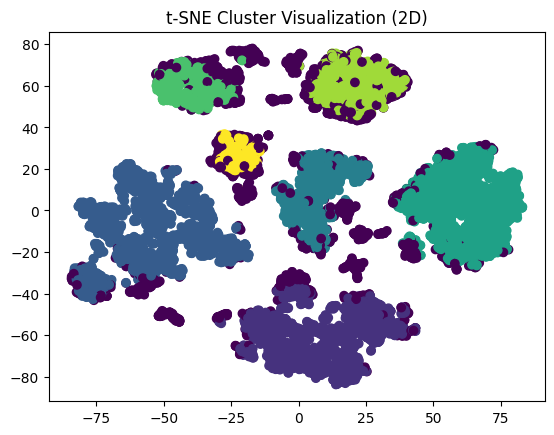

```python
# Visualizing t-SNE reduction
plt.scatter(tsne_result_2d[:, 0], tsne_result_2d[:, 1], c=labels)
plt.title("t-SNE Cluster Visualization (2D)")
plt.show()
```

it found the best fit to be 7 clusters with 1683 outliers in the data which seems convenient as the data already has too many outliers but still not the best clustering result so Random forest isolation can show if this result is convienent or not

### Random Forest Isolation

to detect anomalities

```python
from sklearn.ensemble import IsolationForest
```

```python
iso_forest = IsolationForest(n_estimators=100, contamination=0.05, random_state=42)
labels = iso_forest.fit_predict(log_scaled_data)
```

```python
clusters_1=pd.concat([df, pd.DataFrame({'cluster':labels})], axis=1)
clusters_1.head()
```

|  | BALANCE | BALANCE_FREQUENCY | PURCHASES | ONEOFF_PURCHASES | INSTALLMENTS_PURCHASES | CASH_ADVANCE | PURCHASES_FREQUENCY | ONEOFF_PURCHASES_FREQUENCY | PURCHASES_INSTALLMENTS_FREQUENCY | CASH_ADVANCE_FREQUENCY | PURCHASES_TRX | CREDIT_LIMIT | PAYMENTS | MINIMUM_PAYMENTS | PRC_FULL_PAYMENT | TENURE | cluster |
| --- | --- | --- | --- | --- | --- | --- | --- | --- | --- | --- | --- | --- | --- | --- | --- | --- | --- |
| 0 | 40.900749 | 0.818182 | 95.40 | 0.00 | 95.4 | 0.000000 | 0.166667 | 0.000000 | 0.083333 | 0.000000 | 2.0 | 1000.0 | 201.802084 | 139.509787 | 0.000000 | 12.0 | 1.0 |
| 1 | 3202.467416 | 0.909091 | 0.00 | 0.00 | 0.0 | 6442.945483 | 0.000000 | 0.000000 | 0.000000 | 0.250000 | 0.0 | 7000.0 | 4103.032597 | 1072.340217 | 0.222222 | 12.0 | 1.0 |
| 2 | 2495.148862 | 1.000000 | 773.17 | 773.17 | 0.0 | 0.000000 | 1.000000 | 1.000000 | 0.000000 | 0.000000 | 12.0 | 7500.0 | 622.066742 | 627.284787 | 0.000000 | 12.0 | 1.0 |
| 3 | 1666.670542 | 0.636364 | 1499.00 | 1499.00 | 0.0 | 205.788017 | 0.083333 | 0.083333 | 0.000000 | 0.083333 | 1.0 | 7500.0 | 0.000000 | 864.179560 | 0.000000 | 12.0 | 1.0 |
| 4 | 817.714335 | 1.000000 | 16.00 | 16.00 | 0.0 | 0.000000 | 0.083333 | 0.083333 | 0.000000 | 0.000000 | 1.0 | 1200.0 | 678.334763 | 244.791237 | 0.000000 | 12.0 | 1.0 |

```python
clusters_1['cluster'].value_counts()
```

```
 1.0    8494
-1.0     447
Name: cluster, dtype: int64
```

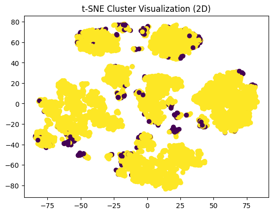

```python
# Visualizing t-SNE reduction
plt.scatter(tsne_result_2d[:, 0], tsne_result_2d[:, 1], c=labels)
plt.title("t-SNE Cluster Visualization (2D)")
plt.show()
```

### GMM

it is best to initialize with kmeans and make covariance type to be full

```python
from sklearn.mixture import GaussianMixture
```

```python
gmm = GaussianMixture( n_components = 7,
    covariance_type = "full",
    init_params =  "kmeans",)
gmm.fit(log_scaled_data)
labels = gmm.predict(log_scaled_data)
```

```python
clusters_1=pd.concat([df, pd.DataFrame({'cluster':labels})], axis=1)
clusters_1.head()
```

|  | BALANCE | BALANCE_FREQUENCY | PURCHASES | ONEOFF_PURCHASES | INSTALLMENTS_PURCHASES | CASH_ADVANCE | PURCHASES_FREQUENCY | ONEOFF_PURCHASES_FREQUENCY | PURCHASES_INSTALLMENTS_FREQUENCY | CASH_ADVANCE_FREQUENCY | PURCHASES_TRX | CREDIT_LIMIT | PAYMENTS | MINIMUM_PAYMENTS | PRC_FULL_PAYMENT | TENURE | cluster |
| --- | --- | --- | --- | --- | --- | --- | --- | --- | --- | --- | --- | --- | --- | --- | --- | --- | --- |
| 0 | 40.900749 | 0.818182 | 95.40 | 0.00 | 95.4 | 0.000000 | 0.166667 | 0.000000 | 0.083333 | 0.000000 | 2.0 | 1000.0 | 201.802084 | 139.509787 | 0.000000 | 12.0 | 2.0 |
| 1 | 3202.467416 | 0.909091 | 0.00 | 0.00 | 0.0 | 6442.945483 | 0.000000 | 0.000000 | 0.000000 | 0.250000 | 0.0 | 7000.0 | 4103.032597 | 1072.340217 | 0.222222 | 12.0 | 4.0 |
| 2 | 2495.148862 | 1.000000 | 773.17 | 773.17 | 0.0 | 0.000000 | 1.000000 | 1.000000 | 0.000000 | 0.000000 | 12.0 | 7500.0 | 622.066742 | 627.284787 | 0.000000 | 12.0 | 3.0 |
| 3 | 1666.670542 | 0.636364 | 1499.00 | 1499.00 | 0.0 | 205.788017 | 0.083333 | 0.083333 | 0.000000 | 0.083333 | 1.0 | 7500.0 | 0.000000 | 864.179560 | 0.000000 | 12.0 | 0.0 |
| 4 | 817.714335 | 1.000000 | 16.00 | 16.00 | 0.0 | 0.000000 | 0.083333 | 0.083333 | 0.000000 | 0.000000 | 1.0 | 1200.0 | 678.334763 | 244.791237 | 0.000000 | 12.0 | 3.0 |

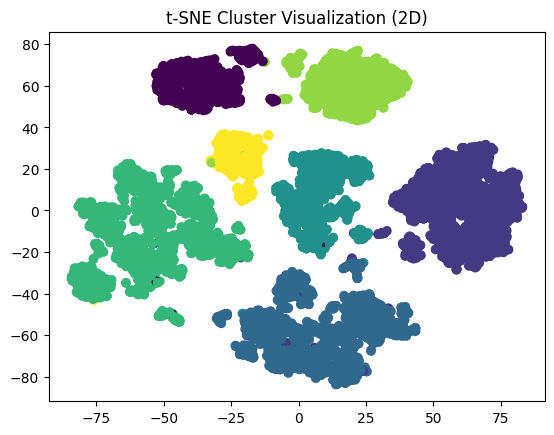

```python
# Visualizing t-SNE reduction
plt.scatter(tsne_result_2d[:, 0], tsne_result_2d[:, 1], c=labels)
plt.title("t-SNE Cluster Visualization (2D)")
plt.show()
```

all of the different algorithms shows that these are the 7 clusters in data but this seems like the most accurate

## 6. improvement ideas

(Go to top)

- Try different technique to deal with outliers other than log scaling
- Try to use PCA to reduce the number of features and compare how this will affect the clustring process
- Try to run your code again but with different tranformation technique
- Implement gap statistics method and use it as evaluation metric and compare the result with what you did before https://www.datanovia.com/en/lessons/determining-the-optimal-number-of-clusters-3-must-know-methods/#gap-statistic-method